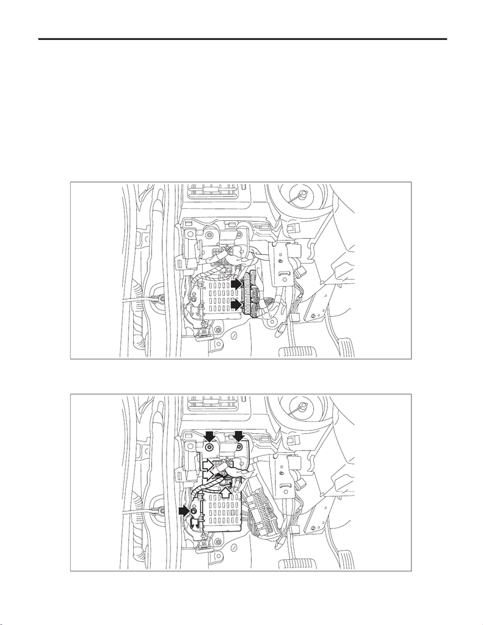

LI-71

Auto Headlight Beam Leveler Control Module

LIGHTING SYSTEM

38.Auto Headlight Beam Leveler Control Module

A: REMOVAL

CAUTION:

Before handling the airbag module, refer to “CAUTION” of “General Description” in “AIRBAG SYS-

TEM”. <Ref. to AB-9, CAUTION, General Description.>

1) Disconnect the battery ground cable and wait for at least 60 seconds before starting work. <Ref. to NT-5,

BATTERY, NOTE, Note.>

NOTE:

For models other than STI model, disconnect the ground terminal from battery sensor.

2) Remove the instrument panel lower cover. <Ref. to EI-61, REMOVAL, Instrument Panel Lower Cover.>

3) Remove the knee airbag module. <Ref. to AB-35, REMOVAL, Knee Airbag Module.>

4) Release the lock and remove the fuse holder.

5) Remove the relay & fuse box.

(1) Disconnect the connector.

(2) Remove the bolts and nuts, and remove the relay & fuse box.

SL-01530

SL-01531

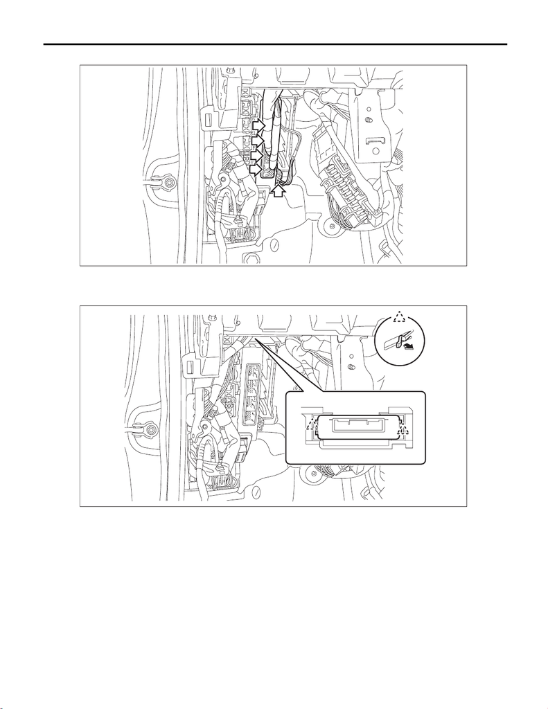

LI-72

Auto Headlight Beam Leveler Control Module

LIGHTING SYSTEM

6) Disconnect the connector of body integrated unit.

7) Remove the auto headlight beam leveler CM.

(1) Disconnect the connector.

(2) Release the claws and pull out the auto headlight beam leveler CM.

SL-01532

LI-01260

[figure not shown]

LI-73

Auto Headlight Beam Leveler Control Module

LIGHTING SYSTEM

B: INSTALLATION

CAUTION:

Before handling the airbag module, refer to “CAUTION” of “General Description” in “AIRBAG SYS-

TEM”. <Ref. to AB-9, CAUTION, General Description.>

1) Install the auto headlight beam leveler CM.

2) Install the relay & fuse box.

Tightening torque:

7.5 N·m (0.8 kgf-m, 5.5 ft-lb)

3) Install the fuse holder.

4) Install the knee airbag module.

Tightening torque:

7.5 N·m (0.8 kgf-m, 5.5 ft-lb)

5) Install the instrument panel lower cover.

6) Connect the battery ground terminal. <Ref. to NT-5, BATTERY, NOTE, Note.>

NOTE:

For models other than STI model, connect the ground terminal to battery sensor.

7) Perform initialization and reinitialization of the auto headlight beam leveler system. <Ref. to LI-16, PRO-

CEDURE, Auto Headlight Beam Leveler System.>